# Homework 03

Xiao, Justin (email: BOX11@pitt.edu)

today

# Overview

> You’ll use the `adult.csv` data for this assignment. Description of the dataset can be found in the file `adult.txt`. The dataset is down-sampled from [UCI Adult Dataset](https://archive.ics.uci.edu/ml/datasets/Adult). The dataset you will use in the homework contains census data of 1000 individuals.

> The objective of this assignment is to predict whether a person earns more than 50K (salary = `>50K`) or not, based on the data. You can extend the samle R code for this assignment: `hw03-sample.R`

Task: Apply different classification techniques (including logistic regression, kNN, Naive Bayesian, decision tree, SVM, and Ensemble methods) on this dataset. Use all available predictors in your models.

1). Use a 10-fold cross-validation to evaluate different classification techniques.

1a). Report your 10-fold CV classification results in a performance table shown below. In the table, report the values of different performance measures for each classification technique. For example, you will generate a table like:

| Tables | logistic | KNN | NB | Decision tree | SVM | Ensemble |
| --- | --- | --- | --- | --- | --- | --- |
| accuracy |  |  |  |  |  |  |
| precision |  |  |  |  |  |  |
| recall |  |  |  |  |  |  |
| F1 |  |  |  |  |  |  |
| AUC |  |  |  |  |  |  |

1b). Generate two bar charts, one for F-score and one for AUC, that allow for visually comparing different classification techniques.

2). Report at least two variants for techniques with parameters and incorporate them into your table. For examples, for kNN, you may include kNN-1, kNN-3, kNN-5. For decision tree, you may include the default tree, and a tree after pruning. For SVM, you may include different kernels and gamma/cost parameters.

3). Generate a plot for the ROC curves of each technique from your table into the same figure and include a legend to indicate the name of each curve. For techniques with variants, plot the best curve that has the highest AUC.

4). In 1-2 paragraphs, summarize the model performance based on your table and the ROC plot (e.g., which one performs the best, the worse, and how).

**hint: Coerce the categorical variables into discrete numbers because some of the techniques (e.g., kNN) cannot take categorical variables as input.**

# Task 1: Use a 10-fold cross-validation to evaluate different classification techniques.

```r
## YOUR CODE HERE
library(car)
library(class)
library(cluster)
library(tree)
library(e1071)
library(MASS)
library(ada)
library(pROC)
library(ROCR)

set.seed(1)
adult <- read.csv("adult.csv")
adult <- na.omit(adult)

adult$salary = factor(car::recode(adult$salary,"' >50K'=1;else=0"))
adult$work = as.factor(adult$work)
adult$realtoin = as.factor(adult$relation)
adult$race = as.factor(adult$race)
adult$sex = as.factor(adult$sex)
adult$age = as.numeric(adult$age)
adult$fnlwgt = as.numeric(adult$fnlwgt)
adult$edu_num = as.numeric(adult$edu_num)
adult$cap_gain = as.numeric(adult$cap_gain)
adult$cap_loss = as.numeric(adult$cap_loss)
adult$hours = as.numeric(adult$hours)
Xadult = model.matrix(salary~.,data=adult)[,-1]

adult<-adult[sample(nrow(adult)),]

k = 10
folds <- cut(seq(1,nrow(adult)),breaks=k,labels=FALSE)

accuracy <- matrix(NA, nrow=6, ncol=k)
precision <- matrix(NA, nrow=6, ncol=k)
recall <- matrix(NA, nrow=6, ncol=k)
F1 <- matrix(NA, nrow=6, ncol=k)
AUC <- matrix(NA, nrow=6, ncol=k)
ROC_curves <- NULL

for (i in 1:k){
  testIndices <- which(folds==i,arr.ind=TRUE)
  xtest <- Xadult[testIndices, ]
  xtrain <- Xadult[-testIndices, ]
  ytest <- adult$salary[testIndices]
  ytrain  <- adult$salary[-testIndices]

  dtest = adult[testIndices,]
  dtrain = adult[-testIndices,]

  answers <- adult[testIndices,]$salary

  model <- glm(salary~.,family=binomial,data=dtrain)

  results_prob <- predict(model,newdata=dtest,type='response')
  btest <- floor(results_prob+0.5)

  confMat = table(dtest$salary, btest)
  TP <- confMat[2,2]
  FP <- confMat[2,1]
  TN <- confMat[1,1]
  FN <- confMat[1,2]

  accuracy[1,i] <- (TP + TN)/nrow(dtest)
  precision[1,i] <- TP/(TP+FP)
  recall[1,i] <- TP/(TP+FN)
  F1[1,i] <- (2*precision[1,i]*recall[1,i])/(precision[1,i]+recall[1,i])

  pr <- prediction(as.numeric(btest), as.numeric(dtest$salary))
  prf <- performance(pr, measure = "tpr", x.measure = "fpr")
  auc_ <- performance(pr, measure = "auc")
  auc_ <- auc_@y.values[[1]]
  AUC[1,i] <- auc_

  roc_logistic <- roc(dtest$salary, as.numeric(btest))

  results <- knn(train=data.frame(xtrain),test=data.frame(xtest),cl=ytrain,k=1)

  TP = sum(answers == 1 & results == 1)
  FN = sum(answers == 0 & results == 1)
  FP = sum(answers == 1 & results == 0)
  TN = sum(answers == 0 & results == 0)

  accuracy[2,i] <- sum(TP + TN)/nrow(dtest)
  precision[2,i] <- TP/(TP+FP)
  recall[2,i] <- TP/(TP+FN)
  F1[2,i] <- (2*precision[2,i]*recall[2,i])/(precision[2,i]+recall[2,i])

  pr <- prediction(as.numeric(results), as.numeric(dtest$salary))
  prf <- performance(pr, measure = "tpr", x.measure = "fpr")
  auc_ <- performance(pr, measure = "auc")
  auc_ <- auc_@y.values[[1]]
  AUC[2,i] <- auc_

  roc_knn <- roc(dtest$salary, as.numeric(results))

  model <- naiveBayes(salary~., data=dtrain)
  pred <- predict(model, dtest, type="class")

  confMat = table(dtest$salary, pred)
  TP <- confMat[2,2]
  FP <- confMat[2,1]
  TN <- confMat[1,1]
  FN <- confMat[1,2]

  accuracy[3,i] <- sum(TP + TN)/nrow(dtest)
  precision[3,i] <- TP/(TP+FP)
  recall[3,i] <- TP/(TP+FN)
  F1[3,i] <- (2*precision[3,i]*recall[3,i])/(precision[3,i]+recall[3,i])

  pr <- prediction(as.numeric(pred), as.numeric(dtest$salary))
  prf <- performance(pr, measure = "tpr", x.measure = "fpr")
  auc_ <- performance(pr, measure = "auc")
  auc_ <- auc_@y.values[[1]]
  AUC[3,i] <- auc_

  roc_nb <- roc(dtest$salary, as.numeric(pred))

  salaryTree <- tree(salary~.,data=dtrain, mincut=1)

  results_prob <- predict(salaryTree, dtest, type="class")

  confMat <- table(dtest$salary, results_prob)
  TP <- confMat[2,2]
  FP <- confMat[2,1]
  TN <- confMat[1,1]
  FN <- confMat[1,2]

  accuracy[4,i] <- sum(TP + TN)/nrow(dtest)
  precision[4,i] <- TP/(TP+FP)
  recall[4,i] <- TP/(TP+FN)
  F1[4,i] <- (2*precision[4,i]*recall[4,i])/(precision[4,i]+recall[4,i])

  pr <- prediction(as.numeric(results_prob), as.numeric(dtest$salary))
  prf <- performance(pr, measure = "tpr", x.measure = "fpr")
  auc_ <- performance(pr, measure = "auc")
  auc_ <- auc_@y.values[[1]]
  AUC[4,i] <- auc_

  roc_decision <- roc(dtest$salary, as.numeric(results_prob))

  model <- svm(salary~., data = dtrain)
  prediction <- predict(model, dtest[,-11])

  confMat = table(dtest$salary, prediction)
  TP <- confMat[2,2]
  FP <- confMat[2,1]
  TN <- confMat[1,1]
  FN <- confMat[1,2]

  accuracy[5,i] <- sum(TP + TN)/nrow(dtest)
  precision[5,i] <- TP/(TP+FP)
  recall[5,i] <- TP/(TP+FN)
  F1[5,i] <- (2*precision[5,i]*recall[5,i])/(precision[5,i]+recall[5,i])

  pr <- prediction(as.numeric(prediction), as.numeric(dtest$salary))
  prf <- performance(pr, measure = "tpr", x.measure = "fpr")
  auc_ <- performance(pr, measure = "auc")
  auc_ <- auc_@y.values[[1]]
  AUC[5,i] <- auc_

  roc_svm <- roc(dtest$salary, as.numeric(prediction))

  model <- ada(salary~., data = dtrain)
  prediction <- predict(model, dtest[,-11])

  confMat = table(dtest$salary, prediction)
  TP <- confMat[2,2]
  FP <- confMat[2,1]
  TN <- confMat[1,1]
  FN <- confMat[1,2]

  accuracy[6,i] <- sum(TP + TN)/nrow(dtest)
  precision[6,i] <- TP/(TP+FP)
  recall[6,i] <- TP/(TP+FN)
  F1[6,i] <- (2*precision[6,i]*recall[6,i])/(precision[6,i]+recall[6,i])

  pr <- prediction(as.numeric(prediction), as.numeric(dtest$salary))
  prf <- performance(pr, measure = "tpr", x.measure = "fpr")
  auc_ <- performance(pr, measure = "auc")
  auc_ <- auc_@y.values[[1]]
  AUC[6,i] <- auc_

  roc_ensemble <- roc(dtest$salary, as.numeric(prediction))
}

accs = rowMeans(accuracy)
pres = rowMeans(precision)
recs = rowMeans(recall)
f1s = rowMeans(F1)
aucs = rowMeans(AUC)
tab <- matrix(c(accs, pres, recs, f1s, aucs), ncol=6, byrow=TRUE)
```

## Task 1a: Report your 10-fold CV classification results in a performance table.

```r
## YOUR CODE HERE
colnames(tab) <- c('logistic', 'KNN', 'NB', 'DecisionTree', 'SVM', 'Ensemble')
rownames(tab) <- c('accuracy', 'precision', 'recall', 'F1', 'AUC')
tab <- as.table(tab)
tab
```

```
##            logistic       KNN        NB DecisionTree       SVM  Ensemble
## accuracy  0.8370000 0.6380000 0.8280000    0.8280000 0.8300000 0.8270000
## precision 0.5532949 0.2383441 0.5950235    0.6038134 0.4092351 0.5221464
## recall    0.6974539 0.2367305 0.6512161    0.6621380 0.7480435 0.6727193
## F1        0.6083317 0.2329325 0.6142634    0.6215959 0.5196446 0.5826374
## AUC       0.7389436 0.4991103 0.7475006    0.7500187 0.6830533 0.7206754
```

## Task 1b: Generate two bar charts

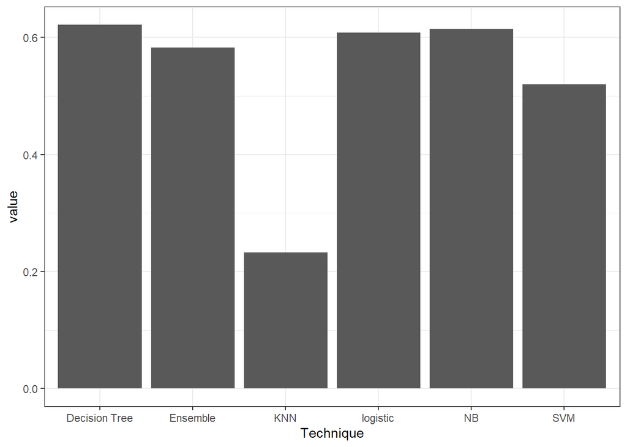

```r
## YOUR CODE HERE
f1_bar = data.frame(Technique=c('logistic', 'KNN', 'NB', 'Decision Tree', 'SVM', 'Ensemble'),
                    value=f1s)
p<-ggplot(data=f1_bar, aes(x=Technique, y=value)) +
  geom_bar(stat="identity")
p
```

[figure not shown]

```r
auc_bar = data.frame(Technique=c('logistic', 'KNN', 'NB', 'Decision Tree', 'SVM', 'Ensemble'),
                    value=aucs)
p2<-ggplot(data=f1_bar, aes(x=Technique, y=value)) +
  geom_bar(stat="identity")
p2
```

# Task 2. Report at least two variants for techniques with parameters and incorporate them into your table.

```r
## YOUR CODE HERE
k=10
# create vectors
accuracy2 <- matrix(NA, nrow=2, ncol=k)
precision2 <- matrix(NA, nrow=2, ncol=k)
recall2 <- matrix(NA, nrow=2, ncol=k)
F12 <- matrix(NA, nrow=2, ncol=k)
AUC2 <- matrix(NA, nrow=2, ncol=k)

# 10 fold cross validation
for (i in 1:k){
  # segment data by fold
  testIndices <- which(folds==i,arr.ind=TRUE)
  xtest <- Xadult[testIndices, ]
  xtrain <- Xadult[-testIndices, ]
  ytest <- adult$salary[testIndices]
  ytrain  <- adult$salary[-testIndices]

  dtest = adult[testIndices,]
  dtrain = adult[-testIndices,]

  # Actual answers
  answers <- adult[testIndices,]$salary

  # ----- KNN 5 -------------------------------------
  # nearest 5
  results <- knn(train=data.frame(xtrain),test=data.frame(xtest),cl=ytrain,k=5)

  # confusion matrix
  TP = sum(answers == 1 & results == 1)
  FN = sum(answers == 0 & results == 1)
  FP = sum(answers == 1 & results == 0)
  TN = sum(answers == 0 & results == 0)

  # performance calculations
  accuracy2[1,i] <- sum(TP + TN)/nrow(dtest)
  precision2[1,i] <- TP/(TP+FP)
  recall2[1,i] <- TP/(TP+FN)
  F12[1,i] <- (2*precision[1,i]*recall[1,i])/(precision[1,i]+recall[1,i])
  # NEED TO CALCULATE AUC
  pr <- prediction(as.numeric(results), as.numeric(dtest$salary))
  prf <- performance(pr, measure = "tpr", x.measure = "fpr")
  auc_ <- performance(pr, measure = "auc")
  auc_ <- auc_@y.values[[1]]
  AUC2[1,i] <- auc_

  # add ROC curve
  roc_knn5 <- roc(dtest$salary, as.numeric(results))

  # ----- Decision Tree ---------------------------
  # model fitting
  salaryTree <- tree(salary~.,data=dtrain, mincut=1)

  # prune tree
  salaryCut <- prune.tree(salaryTree, best=5)

  # make predictions
  results_prob <- predict(salaryCut, dtest, type="class")

  # confusion matrix
  confMat <- table(dtest$salary, results_prob)
  TP <- confMat[2,2]
  FP <- confMat[2,1]
  TN <- confMat[1,1]
  FN <- confMat[1,2]

  # performance calculations
  accuracy2[2,i] <- sum(TP + TN)/nrow(dtest)
  precision2[2,i] <- TP/(TP+FP)
  recall2[2,i] <- TP/(TP+FN)
  F12[2,i] <- (2*precision[2,i]*recall[2,i])/(precision[2,i]+recall[2,i])
  # NEED TO CALCULATE AUC
  pr <- prediction(as.numeric(results_prob), as.numeric(dtest$salary))
  prf <- performance(pr, measure = "tpr", x.measure = "fpr")
  auc_ <- performance(pr, measure = "auc")
  auc_ <- auc_@y.values[[1]]
  AUC2[2,i] <- auc_

  # add ROC curve
  roc_prune <- roc(dtest$salary, as.numeric(results_prob))

}

# concatenate test data
accs2 = rowMeans(accuracy2)
pres2 = rowMeans(precision2)
recs2 = rowMeans(recall2)
f1s2 = rowMeans(F12)
aucs2 = rowMeans(AUC2)
tab2 <- matrix(c(accs2, pres2, recs2, f1s2, aucs2), ncol=2, byrow=TRUE)

# concatenate matricies
tab3 <- cbind(tab,tab2)
# create table
colnames(tab3) <- c('logistic', 'KNN', 'NB', 'DecisionTree', 'SVM', 'Ensemble', 'KNN-5', 'PDT')
rownames(tab3) <- c('accuracy', 'precision', 'recall', 'F1', 'AUC')
tab3 <- as.table(tab3)
tab3
```

```
##             logistic        KNN         NB DecisionTree        SVM   Ensemble
## accuracy  0.83700000 0.63800000 0.82800000   0.82800000 0.83000000 0.82700000
## precision 0.55329487 0.23834414 0.59502352   0.60381337 0.40923515 0.52214644
## recall    0.69745392 0.23673049 0.65121613   0.66213802 0.74804346 0.67271927
## F1        0.60833168 0.23293245 0.61426336   0.62159592 0.51964462 0.58263737
## AUC       0.73894358 0.49911033 0.74750056   0.75001865 0.68305334 0.72067540
##                KNN-5        PDT
## accuracy  0.71600000 0.83700000
## precision 0.08277185 0.52077082
## recall    0.20748307 0.70204298
## F1        0.60833168 0.23293245
## AUC       0.49544449 0.72648478
```

# Task 3. Generate an ROC plot

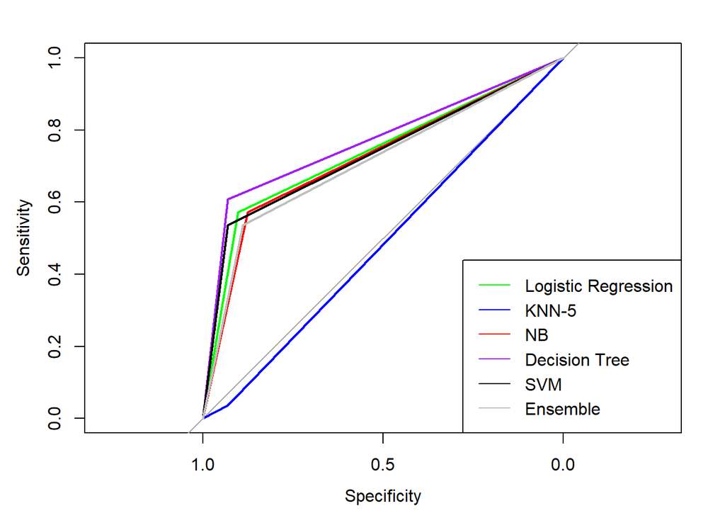

```r
## YOUR CODE HERE
plot(roc_logistic, col="green")
plot(roc_knn5, add=TRUE, col="blue")
plot(roc_nb, add=TRUE, col="red")
plot(roc_decision, add=TRUE, col="purple")
plot(roc_svm, add=TRUE, col="black")
plot(roc_ensemble, add=TRUE, col="grey")
legend("bottomright",c("Logistic Regression","KNN-5","NB","Decision Tree","SVM","Ensemble"),col=c("green","blue","red","purple","black","grey"), lty=1)
```

# Task 4. In 1-2 paragraphs, summarize the model performance based on your table and the ROC plot.